# Encontros relâmpagos

6 de outubro de 2016

# Os dados

Os dados descrevem 5000 encontros relâmpagos envolvendo jovens americanos. Cada observação possui informações a respeito do que uma pessoa achou da outra sob vários aspectos (por exemplo o quão a outra pessoa era atraente, o quão a outra pessoa era inteligente, o quão era ambiciosa, tudo isso sob a ótica da pessoa que avaliou, dando notas de 0 a 10 para cada quesito). No fim, a pessoa faz uma avaliação geral sobre com quem se encontrou.

```r
ler_dados <- function(arquivo){
  require("dplyr", warn.conflicts = FALSE)

  dados = read.csv(arquivo, stringsAsFactors = FALSE, encoding='UTF-8')
  return(dados)
}

speed_datings = ler_dados("../dados/speed-dating.csv")

datings = speed_datings %>% select(2, 5, 30, 32, 33, 35, 36, 37)
```

## Entre os atributos aparência e inteligência, qual explica melhor a nota recebida por uma pessoa?

É algo até lógico que quanto mais inteligente e atraente uma pessoa acha a outra, maior deve ser a avaliação da mesma. Mas qual a que exerce maior influência sobre o like?

Abaixo temos o gráfico de dispersão relacionando os dois atributos citados e o like, separadamente. Conforme imaginado, vemos certa linearidade entre as variáveis.

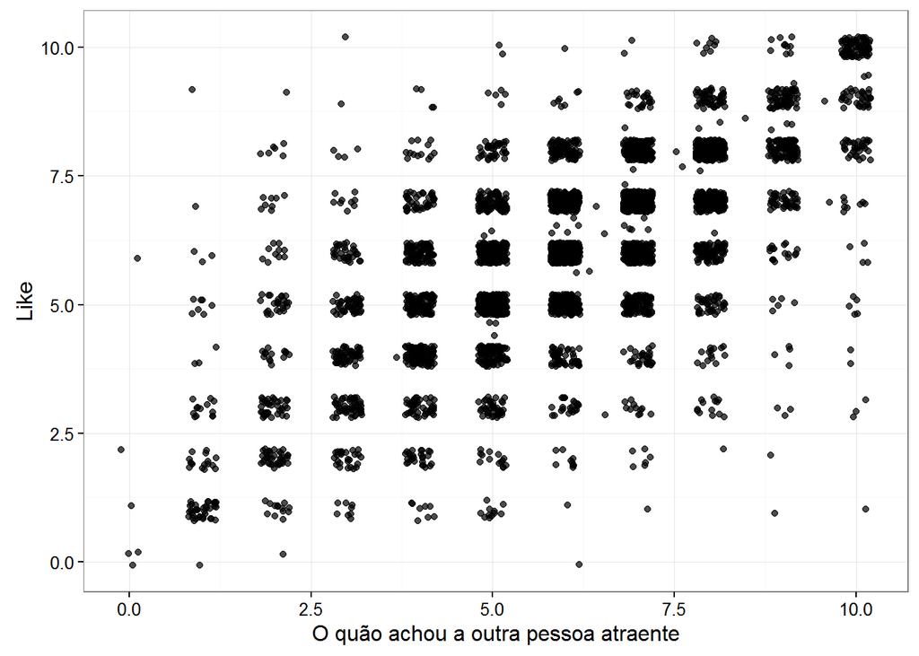

```r
ggplot(datings, aes(x = attr, y = like)) +
  geom_point(alpha = 0.7, position = position_jitter()) +
  xlab("O quão achou a outra pessoa atraente") +
  ylab("Like")
```

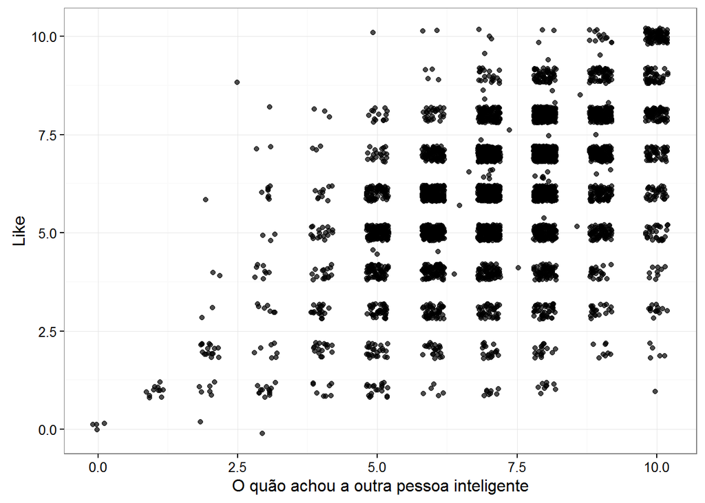

```r
ggplot(datings, aes(x = intel, y = like)) +
  geom_point(alpha = 0.7, position = position_jitter()) +
  xlab("O quão achou a outra pessoa inteligente") +
  ylab("Like")
```

# MRLS para relacionar o quão uma pessoa acha a outra atraente e like

Podemos ver que o quão uma pessoa acha a outra atraente exerce uma influência significativa, já que o modelo possui um p-value muito pequeno e o coeficiente estimado possui um intervalo de confiança que não contém o 0, estando entre 0.61 e 0.65. Levando em conta os valores estimados, a reta ajustada seria:

like = 0.63*attr + 2.18

Em outras palavras, a cada ponto aumentado no quão uma pessoa acha a outra atraente, a avaliação (like) aumentaria em 0.63.

O R² observado indica que a nossa variável explicativa explica 45% das variabilidade total da nossa variável dependente (like).

Analisando os resíduos, os gráficos parecem indicar que não há correlação entre os resíduos e os valores ajustados, e o gráfico Q-Q mostra vários pontos passando pela reta traçada. Quanto mais pontos passando pela reta (ou próximos), maior a normalidade dos erros (resíduos), indicando um bom ajuste dos dados ao modelo.

```r
lm_attr_like <- lm(like ~ attr, data = datings)
tidy(lm_attr_like, conf.int = TRUE)
```

```
##          term  estimate  std.error statistic       p.value  conf.low
## 1 (Intercept) 2.1825407 0.06487213  33.64373 6.484123e-223 2.0553614
## 2        attr 0.6378654 0.01018173  62.64806  0.000000e+00 0.6179045
##   conf.high
## 1 2.3097199
## 2 0.6578263
```

```r
glance(lm_attr_like)
```

```
##   r.squared adj.r.squared   sigma statistic p.value df    logLik      AIC
## 1  0.450721     0.4506062 1.37309  3924.779       0  2 -8305.772 16617.54
##        BIC deviance df.residual
## 1 16636.96 9017.759        4783
```

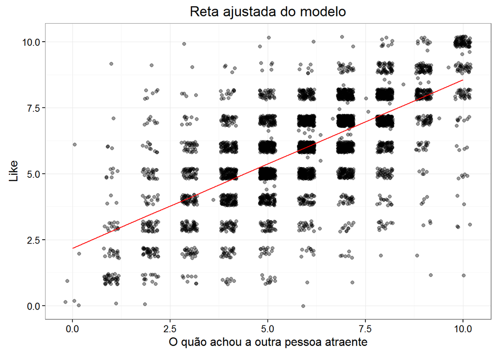

```r
ggplot(datings, aes(x = attr, y = like)) +
  geom_point(alpha = 0.4, position = position_jitter()) +
  geom_line(aes(y = predict(lm_attr_like, datings)), colour = "red") +
  xlab("O quão achou a outra pessoa atraente") +
  ylab("Like") +
  ggtitle("Reta ajustada do modelo")
```

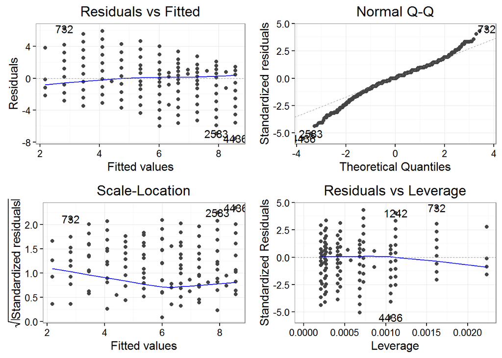

```r
autoplot(lm_attr_like)
```

# MRLS para relacionar inteligência e like

Em outras palavras, a cada ponto aumentado no quão uma pessoa acha a outra inteligente, a avaliação (like) aumentaria em 0.59.

Analisando os resíduos, os gráficos parecem indicar que não há correlação entre os resíduos e os valores ajustados, e o gráfico Q-Q mostra vários pontos passando pela reta traçada, mais até do que na análise anterior.

```r
lm_intel_like <- lm(like ~ intel, data = datings)
tidy(lm_intel_like, conf.int = TRUE)
```

```
##          term  estimate  std.error statistic       p.value  conf.low
## 1 (Intercept) 1.7303055 0.10869730  15.91857  1.275341e-55 1.5172083
## 2       intel 0.5947759 0.01461394  40.69922 8.067725e-311 0.5661258
##   conf.high
## 1  1.943403
## 2  0.623426
```

```r
glance(lm_intel_like)
```

```
##   r.squared adj.r.squared    sigma statistic       p.value df    logLik
## 1 0.2590827     0.2589263 1.593272  1656.426 8.067725e-311  2 -8930.727
##        AIC      BIC deviance df.residual
## 1 17867.45 17886.84 12024.95        4737
```

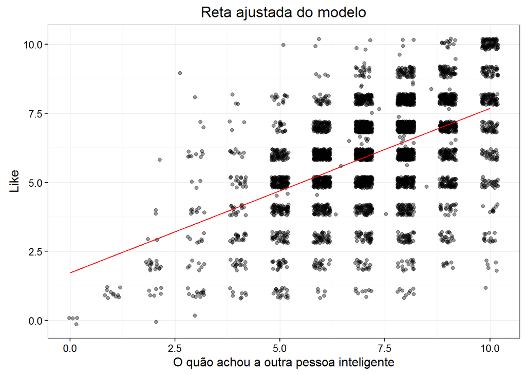

```r
ggplot(datings, aes(x = intel, y = like)) +
  geom_point(alpha = 0.4, position = position_jitter()) +
  geom_line(aes(y = predict(lm_intel_like, datings)), colour = "red") +
  xlab("O quão achou a outra pessoa inteligente") +
  ylab("Like") +
  ggtitle("Reta ajustada do modelo")
```

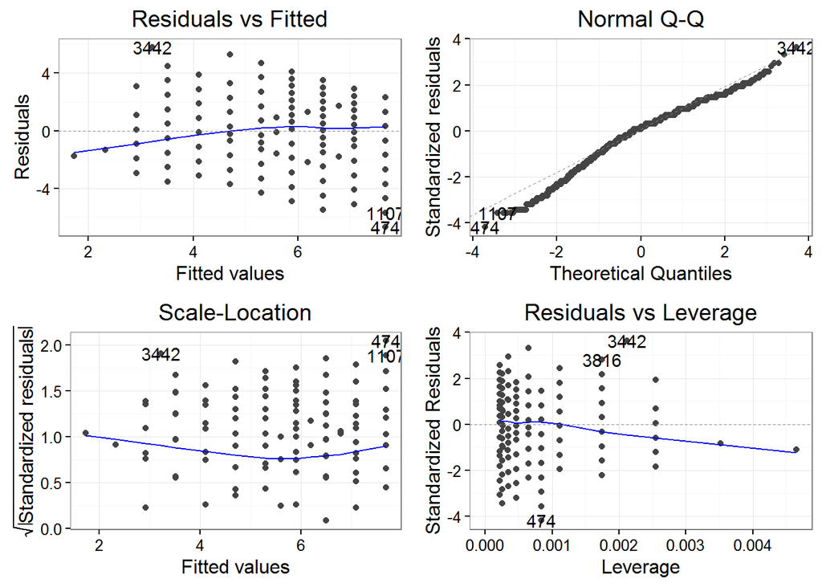

```r
autoplot(lm_intel_like)
```

Apesar de os resultados dos modelos nos levarem a um indicativo que a o quão uma pessoa acha a outra atraente influencia mais na nota atribuída do que a inteligência, não podemos garantir isso com tanta precisão, já que os intervalos de confiança gerados para os coeficientes lineares se interceptam. Por outro lado, olhando para o R², temos que a atratividade explica 45% da variabilidade do like, enquanto que a inteligência apenas 25%.

Fazendo uma regressão linear múltipla com as duas variáveis para verificar o quão as duas juntas explicam a nota, obtemos um R² de 52%, um valor considerado até baixo. Esperava-se que esses dois fatores juntos explicassem bastante a nota, mas isso não ocorre. Talvez se adicionássemos outros atributos como sinceridade, por exemplo, nessa análise, esse valor pudesse aumentar.

```r
mrlm_like <- lm(like ~ intel + attr, data = datings)
tidy(mrlm_like, conf.int = TRUE)
```

```
##          term  estimate  std.error statistic       p.value  conf.low
## 1 (Intercept) 0.3174782 0.09136717  3.474751  5.159176e-04 0.1383560
## 2       intel 0.3472147 0.01266718 27.410583 1.188157e-153 0.3223811
## 3        attr 0.5290944 0.01030163 51.360284  0.000000e+00 0.5088984
##   conf.high
## 1 0.4966004
## 2 0.3720483
## 3 0.5492904
```

```r
glance(mrlm_like)
```

```
##   r.squared adj.r.squared    sigma statistic p.value df    logLik      AIC
## 1 0.5244906     0.5242896 1.276883  2608.614       0  3 -7871.185 15750.37
##        BIC deviance df.residual
## 1 15776.22 7711.935        4730
```

## Em qual gênero o like é mais afetado pelo quão uma pessoa acha a outra ambiciosa?

O gráfico de dispersão abaixo mostra um comportamento dos dados parecido com o que vimos na análise da primeira pergunta. Uma variável explicativa (Aqui, o quão a pessoa que avalia achou a outra ambiciosa) exercendo influência sobre o a nota geral atribuída (like). O objetivo agora é ver o comportamento dessa regressão considerando as avaliações feitas por homens e mulheres de maneira separada. Há muita diferença? Quem se sente mais atraído por outra pessoa devido à uma grande ambição da mesma, os homens ou as mulheres?

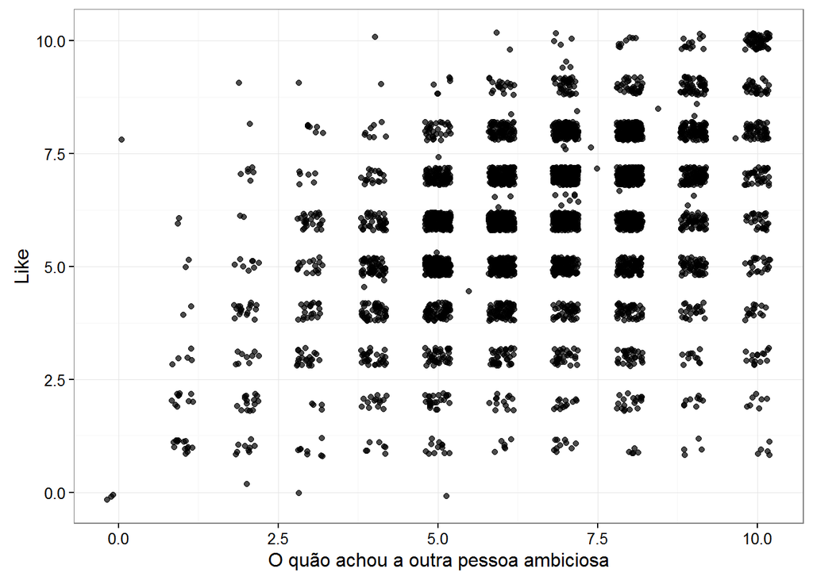

```r
ggplot(speed_datings, aes(x = amb, y = like)) +
  geom_point(alpha = 0.7, position = position_jitter()) +
  xlab("O quão achou a outra pessoa ambiciosa") +
  ylab("Like")
```

# Gênero masculino

Podemos ver que a ambiciosidade da mulher exerce uma influência significativa para os homens, já que o modelo possui um p-value muito pequeno e o coeficiente estimado possui um intervalo de confiança que não contém o 0, estando entre 0.39 e 0.46. Levando em conta os valores estimados, a reta ajustada seria:

like = 0.42*amb + 3.37

O R² observado indica que a nossa variável explicativa ambição explica apenas 18.4% da variabilidade total da nossa variável dependente (like), um valor considerado baixo.

Analisando os resíduos, os gráficos parecem indicar que não há correlação entre os resíduos e os valores ajustados, e o gráfico Q-Q mostra vários pontos passando pela reta traçada, indicando certa normalidade nos erros, o que é um bom indicativo para o modelo.

```r
amostra_homens <- speed_datings %>% filter (gender == 1)

lm_men <- lm(like ~ amb, data = amostra_homens)
tidy(lm_men, conf.int = TRUE)
```

```
##          term estimate std.error statistic       p.value  conf.low
## 1 (Intercept) 3.378800 0.1298699  26.01681 1.945888e-130 3.1241206
## 2         amb 0.428994 0.0191749  22.37269 3.996622e-100 0.3913914
##   conf.high
## 1 3.6334796
## 2 0.4665967
```

```r
glance(lm_men)
```

```
##   r.squared adj.r.squared    sigma statistic       p.value df    logLik
## 1 0.1843235     0.1839552 1.584036  500.5373 3.996622e-100  2 -4164.553
##        AIC      BIC deviance df.residual
## 1 8335.105 8352.217 5557.809        2215
```

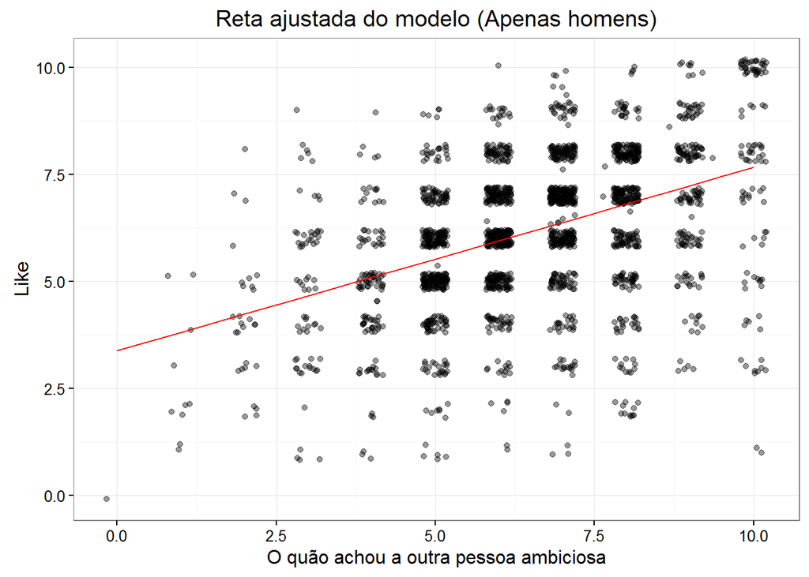

```r
ggplot(amostra_homens, aes(x = amb, y = like)) +
  geom_point(alpha = 0.4, position = position_jitter()) +
  geom_line(aes(y = predict(lm_men, amostra_homens)), colour = "red") +
  xlab("O quão achou a outra pessoa ambiciosa") +
  ylab("Like") +
  ggtitle("Reta ajustada do modelo (Apenas homens)")
```

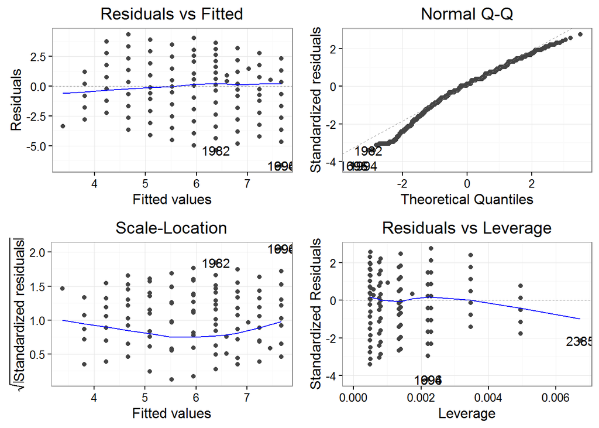

```r
autoplot(lm_men)
```

# Gênero feminino

O resultados foram muito semelhantes aos dos homens e as conclusões feitas anteriormente se aplicam. Agora, o coeficiente linear estimado é 0.43, mas com um intervalo de confiança muito parecido ao encontrado anteriormente.

O R² observado indica que a variável explica 17.9% da variabilidade total da nossa variável dependente, algo bem parecido com o já encontrado antes.

Para os resíduos, também temos algo bem parecido.

```r
amostra_mulheres <- speed_datings %>% filter (gender == 0)

lm_woman <- lm(like ~ amb, data = amostra_mulheres)
tidy(lm_woman, conf.int = TRUE)
```

```
##          term  estimate std.error statistic      p.value  conf.low
## 1 (Intercept) 2.9150929 0.1373917  21.21739 2.786756e-91 2.6456663
## 2         amb 0.4302541 0.0193327  22.25525 2.094035e-99 0.3923424
##   conf.high
## 1 3.1845195
## 2 0.4681657
```

```r
glance(lm_woman)
```

```
##   r.squared adj.r.squared    sigma statistic      p.value df    logLik
## 1 0.1793059     0.1789439 1.741816  495.2961 2.094035e-99  2 -4477.704
##        AIC      BIC deviance df.residual
## 1 8961.408 8978.589 6877.907        2267
```

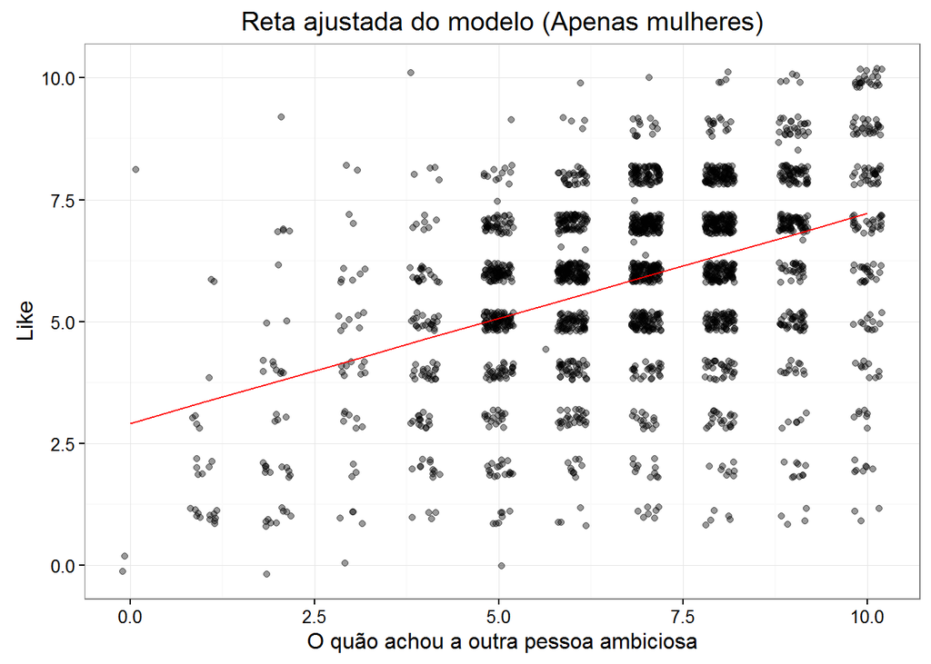

```r
ggplot(amostra_mulheres, aes(x = amb, y = like)) +
  geom_point(alpha = 0.4, position = position_jitter()) +
  geom_line(aes(y = predict(lm_woman, amostra_mulheres)), colour = "red") +
  xlab("O quão achou a outra pessoa ambiciosa") +
  ylab("Like") +
  ggtitle("Reta ajustada do modelo (Apenas mulheres)")
```

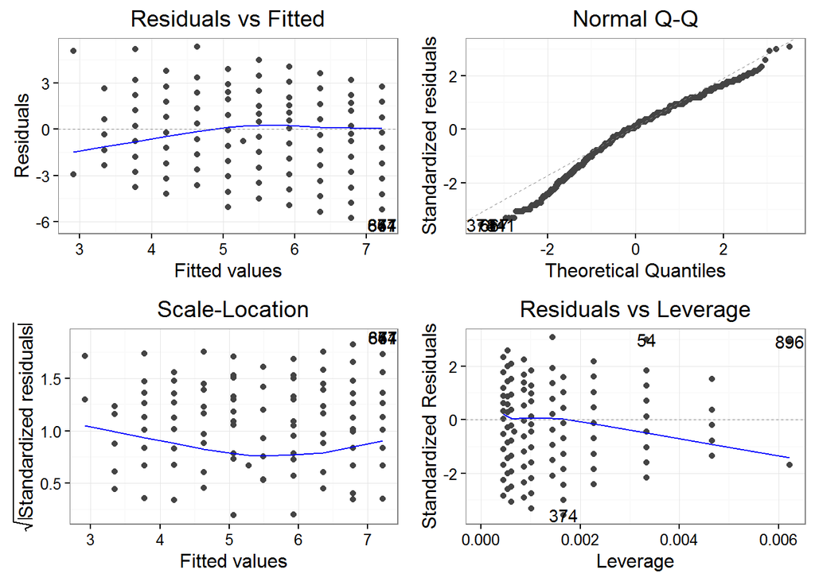

```r
autoplot(lm_woman)
```

Assim, conclui-se que o gênero não é um fator determinante para essa análise. No geral, quanto mais ambiciosa uma pessoa acha a outra, maior deve ser a nota geral atribuída por ela, mas independentemente do gênero.